# SI608 Fall 2025 – Homework 3

**Due:** Wednesday, November 5, 12:00PM EST (noon the day before class)

**Instructions:** Please submit your **.ipynb** and **.html** files and **a text file including your genAI chat history related to this homework** to Canvas. Remember to rename the notebook by filling in your uniqname. If you have *additional* supplementary files (e.g., images), please also attach them in your submission.

**Collaboration policy:** You may work with others on this but specific answers need to be your own. Please indicate with whom you worked when you turn in this assignment.

## **Question 1 |** Clique Percolation Method (CPM)

*[[25 points]]*

### **Q1.1 |** Apply clustering

*[[12 points]]*

Consider the following graph. Apply CPM with k=3 and identify the communities accordingly.

*Please do this by hand and show your work process.*

[figure not shown]

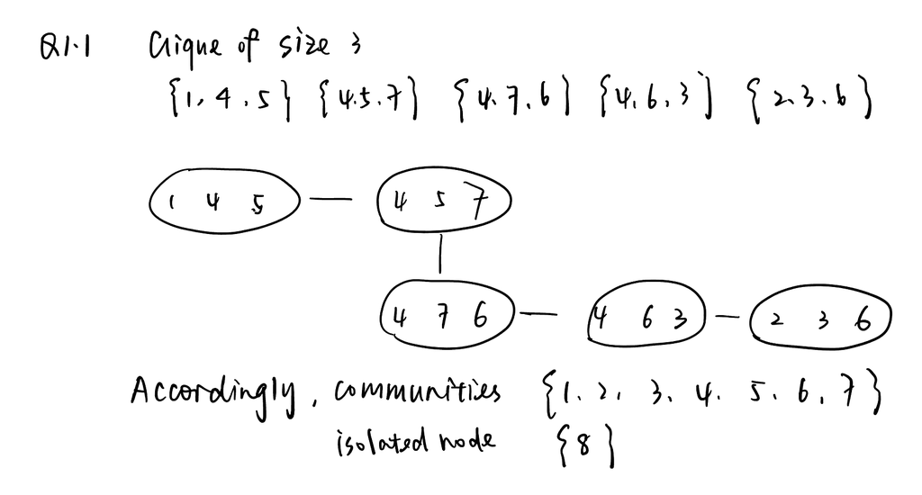

### **Q1.2 |** Compare with ground truth data

*[[13 points]]*

Imagine you learned that there are three real communities:  
C1 = {3,4,6,7}  
C2 = {1,4,5}  
C3 = {2,3}

Calculate the accuracy (using accuracy of pairwise community memberships) of the CPM solution you computed above.

*Please do this by hand and show your work.*

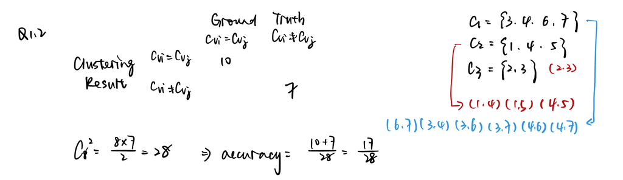

## **Question 2 |** Betweenness Clustering

*[[30 points]]*

In Lab 5 you practiced using `girvan_newman()` to perform betweenness clustering. In this part you'll build the function from scratch to understand how it actually operates. Let's use a random ER graph with parameters: `n = 100`, `p = 0.05`, `seed = 2666` (so that the results are reproducible).

Please read through the psuedo code, complete with your own code, and return the exact output as required.

### **Q2.1 |** Build the function

*[[15 points]]*

```python
# 0. Generate an ER graph (2 point)


# YOUR CODE HERE
import networkx as nx

G_er = nx.erdos_renyi_graph(n = 100, p = 0.05, seed = 2666)
```

```python
# 1. Define a function that returns the most valuable edge in a graph (with the highest betweenness) (2 points)
# - one input, g --> a networkx graph object
# - one output, the most valuable edge; should be a tuple, e.g., (node1, node2)

def fetch_most_valuable_edge(g):

    # YOUR CODE HERE
    # data type: dict
    # key: edge(tuple)
    # value: betweenness
    betweenness = nx.edge_betweenness_centrality(g)

    # ordered by value and return the key
    this_edge = max(betweenness, key = lambda x: betweenness[x])

    return this_edge
```

```python
# 2. Define a function that performs one round of betweenness clustering every time you call it (6 points)
# - two inputs: g and the fetch_edge function (you defined in the last cell)
# - one output: a sorted community list (sorted by community size, descending)
# ---- community list is a list of communities detected, each community itself is a list of nodes
# ---- e.g., for two communities (node a, node b), (node c, node d, node e),
# ---- the output should look like this: [[c,d,e], [a,b]]

def perform_betw_clustering(g, fetch_edge):

    # If the graph is already empty, simply return its connected components.
    if g.number_of_edges() == 0:
        yield list(nx.connected_components(g))

    # use a copy of g so that you won't modify the original graph
    g_cp = g.copy().to_undirected()

    # and remove self-loop
    g_cp.remove_edges_from(nx.selfloop_edges(g))

    # while there are still edges in the graph
    while g_cp.number_of_edges() > 0:

        # YOUR CODE HERE
        # Hint:
        # 1. count # of components
        n1_components = nx.number_connected_components(g_cp)

        # 2. every time you remove one most valuable edge, count # of compoents again
        edge_to_remove = fetch_edge(g_cp)
        g_cp.remove_edge(*edge_to_remove) # unpack the edge tuple
        n2_components = nx.number_connected_components(g_cp) # count components again

        # 3. if the graph breaks into more compoents, stop removing edges
        if n2_components - n1_components > 0 :
            community_list = [list(c) for c in nx.connected_components(g_cp)]
            community_list.sort(key=len, reverse=True)
            yield community_list, g_cp
            break
        # 4. return the community tuple
```

### **Q2.2 |** Test the function

*[[15 points]]*

Now you'll test out your function.

Perform 3 rounds of betweenness clustering on the ER graph (with 100 nodes), and report the following:

- detected communities (print out `community_list`) in each round
- number of communities in each round
- number of edges removed in each round
- max community size in each round (# of nodes in the largest community)
- the modularity score in each round (you can use the modularity in `networkx`)

```python
# YOUR CODE HERE
from networkx.algorithms.community import modularity

current_graph = G_er.copy().to_undirected()
prev_num_edges = current_graph.number_of_edges()

for i in range(3):
    print(f"----Round {i + 1}----")
    result = perform_betw_clustering(current_graph, fetch_most_valuable_edge)
    community_list, new_graph = next(result) # perform_betw_clustering is generator
    current_graph = new_graph.copy()
    print(f"Detected communities: {community_list}")

    n_community = len(community_list)
    print(f"Number of communities: {n_community}")

    edges_removed = prev_num_edges - current_graph.number_of_edges()
    print(f"Edges removed this round: {edges_removed}")

    prev_num_edges = current_graph.number_of_edges()

    max_size = max(len(c) for c in community_list)
    print(f"Max community size: {max_size}")

    mod_score = modularity(current_graph, community_list)
    print(f"Modularity: {mod_score:.4f}")
```

```
----Round 1----
Detected communities: [[0, 1, 2, 3, 4, 5, 6, 7, 8, 9, 10, 11, 12, 13, 14, 15, 16, 17, 18, 19, 20, 21, 22, 23, 24, 25, 26, 27, 28, 29, 30, 31, 32, 33, 34, 35, 36, 37, 38, 39, 40, 41, 42, 43, 44, 45, 46, 47, 48, 49, 50, 51, 52, 53, 54, 55, 56, 57, 58, 59, 60, 61, 62, 63, 64, 65, 66, 67, 68, 69, 70, 71…
Number of communities: 2
Edges removed this round: 1
Max community size: 98
Modularity: 0.0087
----Round 2----
Detected communities: [[0, 1, 3, 4, 5, 6, 7, 8, 9, 10, 11, 12, 13, 14, 15, 16, 17, 18, 19, 20, 21, 22, 23, 24, 25, 26, 27, 28, 29, 30, 32, 33, 34, 35, 37, 38, 39, 40, 41, 42, 43, 44, 45, 46, 47, 48, 49, 51, 52, 53, 54, 55, 56, 57, 58, 59, 60, 61, 62, 63, 64, 65, 66, 67, 68, 69, 70, 71, 72, 73, 74, 7…
Number of communities: 3
Edges removed this round: 11
Max community size: 93
Modularity: 0.0540
----Round 3----
Detected communities: [[0, 1, 3, 4, 5, 6, 7, 9, 10, 11, 12, 13, 14, 15, 16, 17, 19, 20, 21, 22, 23, 24, 25, 26, 27, 28, 29, 30, 32, 33, 34, 35, 37, 38, 39, 40, 41, 42, 43, 44, 45, 46, 47, 48, 49, 51, 52, 53, 54, 55, 56, 57, 58, 59, 60, 61, 62, 63, 64, 65, 66, 67, 68, 69, 70, 71, 72, 73, 74, 75, 76, …
Number of communities: 4
Edges removed this round: 4
Max community size: 90
Modularity: 0.0730
```

## **Question 3 |** Modularity Clustering

*[[25 points]]*

The dataset also contains ground truth data for the communities these researchers belong to. The communities are research communities, that is journal and conference venues where researchers have published at.

You will use a modularity clustering algorithm, and then evaluate how well it detected the research communities using the accuracy of pairwise community memberships.

### **Q3.1 |** Load the graph

*[[3 points]]*

Load the graph in `email-Eu-core.txt` and print out graph information.

```python
# YOUR CODE HERE
g3 = nx.read_edgelist("email-Eu-core.txt", delimiter = " ", create_using = nx.DiGraph)
```

[output not shown]

### **Q3.2 |** Apply modularity clustering

*[[4 points]]*

Find the communities using modularity-based clustering.  
Report 1) the number of communities you found, and 2) the number of nodes in the largest community.

```python
# YOUR CODE HERE
from networkx.algorithms.community import greedy_modularity_communities

# for this function, the result is ordered by the size of communities descendingly
# and return a list
communities_pred = greedy_modularity_communities(g3)

# the number of communities
n_com = len(communities_pred)
print(f"The number of communities: {n_com}")

# the number of communities
n_large = len(communities_pred[1])
print(f"The number of nodes in the largest community: {n_large}")
```

[output not shown]

### **Q3.3 |** Evaluate how well modularity clustering identified the actual communities

*[[18 points]]*

(1) Load the community membership ground-truth data (`email-Eu-core-department-labels_new-format.txt`)

(2) print the number of communities in ground-truth data, and

(3) then compute the accuracy for the communities detected in Q3.2, using accuracy of pairwise community memberships.

```python
# YOUR CODE HERE
communities_true = []

with open('email-Eu-core-department-labels_new-format.txt') as f:
    for line in f:
        # remove leading/trailing whitespace and newline characters
        line = line.strip()

        # if the line is empty, skip
        if line == '':
            continue

        # split the line into separate node IDs (still strings)
        nodes = line.split()

        c = []
        for n in nodes:
            c.append(int(n))

        communities_true.append(c)

# the number of commmunities in ground-truth data
print(f"The number of true communities: {len(communities_true)}")

# pairwise accuracy
true_labels = {}
for i, comm in enumerate(communities_true):
    for node in comm:
        true_labels[node] = i

pred_labels = {}
for i, comm in enumerate(communities_pred):
    for node in comm:
        pred_labels[node] = i

nodes = sorted(true_labels.keys())
n = len(nodes)

correct = 0
total = 0

for i in range(n):
    for j in range(i + 1, n):
        node_i, node_j = nodes[i], nodes[j]

    same_true = (true_labels[node_i] == true_labels[node_j])
    same_pred = (pred_labels.get(node_i) == pred_labels.get(node_j))

    if same_true == same_pred:
        correct += 1

    total += 1

accuracy = correct / total

print(f"The accuracy of pairwise community memberships: {accuracy:.4f}")
```

```
The number of true communities: 42
The accuracy of pairwise community memberships: 0.0239
```

## **Question 4 |** PageRank

*[[20 points]]*

Perform two full iterations of the PageRank update process, clearly showing all intermediate calculations. At the end of each iteration, report the PageRank value for every node.

Your final submission should include:

- The PageRank formula you applied.
- The step-by-step computation for Iteration 1 and Iteration 2.
- The final PageRank values for each node after both iterations.

[figure not shown]

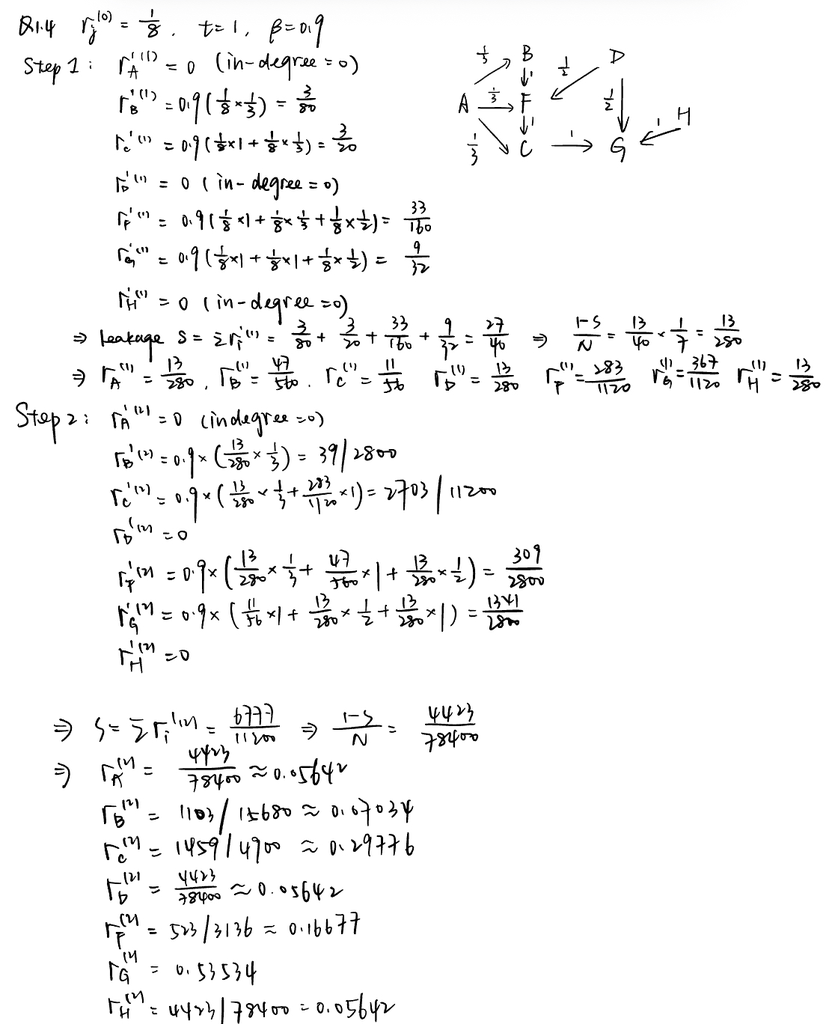